# Objectives and Project Approach

# Appendix C - Demand Response

#### Load Shedding vs Load Shifting on a peak day

This chart compares load shedding and load shifting on a peak demand day. While both reduce the evening peak, shedding cuts demand outright—causing permanent energy loss—whereas shifting redistributes it to off-peak hours, preserving total usage. This makes load shifting more sustainable and user-friendly. For Kaluza, it highlights the value of smart, automated solutions that maintain comfort while easing grid stress.

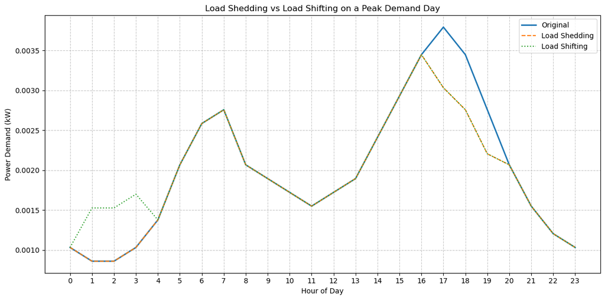

```python
# Simulate a basic daily demand profile (in kW) across 24 hours
hours = np.arange(24)
# Simulated hourly load profile (e.g., low at night, peaks in morning and evening)
baseline_profile = np.array([0.6, 0.5, 0.5, 0.6, 0.8, 1.2, 1.5, 1.6, 1.2, 1.1, 1.0, 0.9,
                             1.0, 1.1, 1.4, 1.7, 2.0, 2.2, 2.0, 1.6, 1.2, 0.9, 0.7, 0.6])

# Normalize to total daily average (scaled up to match peak-day scenario)
peak_day_total_kw = avg_annual_kw / 365 * 1.5  # assume 1.5x daily average for a peak day
scaling_factor = peak_day_total_kw / baseline_profile.sum()
baseline_profile_scaled = baseline_profile * scaling_factor

# Shedding 20% from peak (hours 17-19), shifting to night (hours 1-3)
load_shed = baseline_profile_scaled.copy()
load_shift = baseline_profile_scaled.copy()

# Load Shedding
load_shed[17:20] *= 0.8  # Reduce 20% in peak hours

# Load Shifting
shifted_kw = baseline_profile_scaled[17:20] * 0.2  # Amount to shift
load_shift[17:20] *= 0.8
load_shift[1:4] += shifted_kw.sum() / 3  # redistribute evenly over hours 1–3

# Plotting the profiles
plt.figure(figsize=(12, 6))
plt.plot(hours, baseline_profile_scaled, label="Original", linewidth=2)
plt.plot(hours, load_shed, label="Load Shedding", linestyle='--')
plt.plot(hours, load_shift, label="Load Shifting", linestyle=':')
plt.title("Load Shedding vs Load Shifting on a Peak Demand Day")
plt.xlabel("Hour of Day")
plt.ylabel("Power Demand (kW)")
plt.legend()
plt.grid(True, linestyle='--', alpha=0.7)
plt.xticks(hours)
plt.tight_layout()
plt.show()
```

#### Estimate CO₂ and grid cost savings from DR

This summary outlines the technical, environmental, and financial benefits of implementing a demand response (DR) program at 50% residential adoption. With 60,752 kW of DR potential, the system could avoid 22.17 million kWh of energy annually, saving ~6,652 tonnes of CO₂ and ~$9.1 million in grid costs. These results make a compelling case for scaling DR to support grid flexibility, climate goals, and cost efficiency.

```python
# Assumptions:
# 1 kWh of peak electricity avoided = 0.3 kg CO₂ (typical UK grid intensity)
# Avoided grid infrastructure cost = $150 per kW-year (same as earlier)
co2_per_kwh = 0.3  # kg
grid_cost_avoidance_per_kw = 150  # USD

# Total annual DR potential from earlier full participation: ~60,752 kW
annual_dr_kw = total_annual_demand * 0.5

# Assume each kW of DR represents one hour of demand at peak per day
# So annual avoided energy = 1 kWh/day * 365 days * DR kW
annual_kwh_avoided = annual_dr_kw * 365

# CO2 and cost savings
total_co2_saved_kg = annual_kwh_avoided * co2_per_kwh
total_co2_saved_tonnes = total_co2_saved_kg / 1000

total_grid_savings_usd = annual_dr_kw * grid_cost_avoidance_per_kw

{
    "Total DR Potential (kW)": round(annual_dr_kw, 0),
    "Annual Energy Avoided (kWh)": round(annual_kwh_avoided, 0),
    "CO2 Saved (tonnes)": round(total_co2_saved_tonnes, 0),
    "Grid Cost Savings ($/year)": round(total_grid_savings_usd, 0)
}
```

```
{'Total DR Potential (kW)': 60752.0,
 'Annual Energy Avoided (kWh)': 22174571.0,
 'CO2 Saved (tonnes)': 6652.0,
 'Grid Cost Savings ($/year)': 9112838.0}
```

#### Revenue Distribution

This figure compares five profit-sharing scenarios for revenue from avoided wind curtailment, split among wind farmers, Kaluza, and residents. Higher farmer shares reduce company and household benefits, which may hinder scalability. More balanced splits (e.g., 40-30-30) ensure fairer outcomes—supporting farmer incentives, platform sustainability, and household savings. The analysis supports a flexible, data-driven approach to structuring contracts that align stakeholder interests.

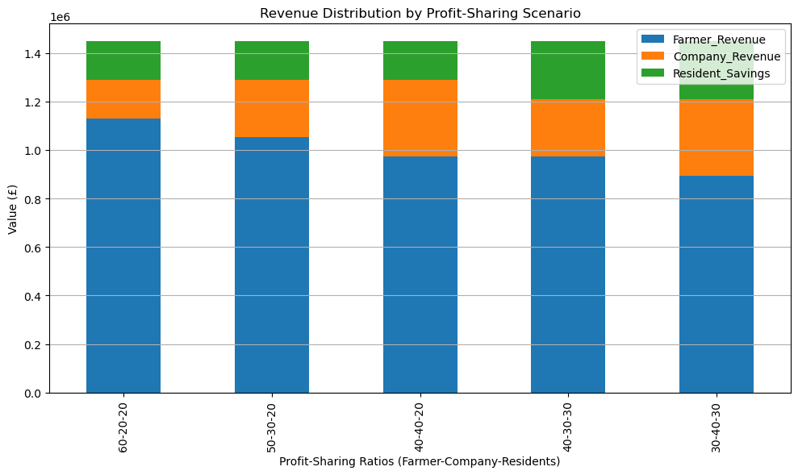

```python
turbine_telemetry = turbine_telemetry.set_index('Timestamp')

# Resample to hourly and prepare clean subset
telemetry_hourly = turbine_telemetry.resample('H').mean()
telemetry_hourly_clean = telemetry_hourly[['Power_kw', 'Setpoint_kw', 'Wind_ms']].dropna()

# Calculate curtailment and other values
telemetry_hourly_clean['Curtailment_kw'] = (telemetry_hourly_clean['Setpoint_kw'] - telemetry_hourly_clean['Power_kw']).clip(lower=0)
wholesale_price = 0.10  # £/kWh

# Run simulation on different ratios
ratios = [(0.6, 0.2, 0.2), (0.5, 0.3, 0.2), (0.4, 0.4, 0.2), (0.4, 0.3, 0.3), (0.3, 0.4, 0.3)]
ratio_labels = ['60-20-20', '50-30-20', '40-40-20', '40-30-30', '30-40-30']

total_avoided_value = telemetry_hourly_clean['Curtailment_kw'].sum() * wholesale_price
baseline_revenue = telemetry_hourly_clean['Power_kw'].sum() * wholesale_price

simulation_results = []
for (farmer_share, company_share, resident_share), label in zip(ratios, ratio_labels):
    simulation_results.append({
        'Scenario': label,
        'Farmer_Revenue': baseline_revenue + total_avoided_value * farmer_share,
        'Company_Revenue': total_avoided_value * company_share,
        'Resident_Savings': total_avoided_value * resident_share
    })

# Convert to DataFrame
simulation_df = pd.DataFrame(simulation_results)

# Plot results
simulation_df.set_index('Scenario').plot(kind='bar', stacked=True, figsize=(10, 6))
plt.title('Revenue Distribution by Profit-Sharing Scenario')
plt.ylabel('Value (£)')
plt.xlabel('Profit-Sharing Ratios (Farmer-Company-Residents)')
plt.grid(axis='y')
plt.tight_layout()
plt.show()
```

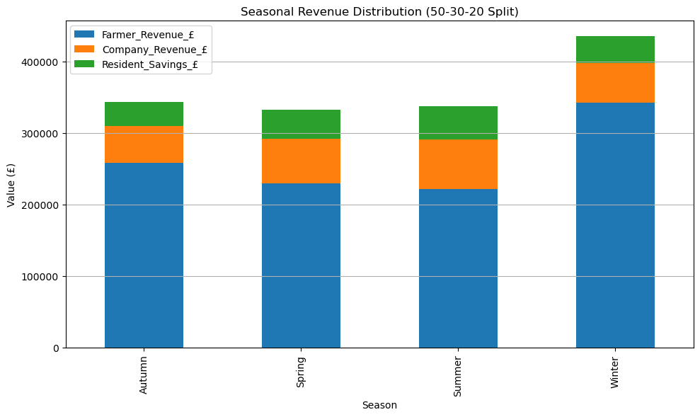

```python
# Add a 'Month' column for seasonal grouping
telemetry_hourly_clean['Month'] = telemetry_hourly_clean.index.month

# Define seasons by grouping months
def month_to_season(month):
    if month in [12, 1, 2]:
        return 'Winter'
    elif month in [3, 4, 5]:
        return 'Spring'
    elif month in [6, 7, 8]:
        return 'Summer'
    else:
        return 'Autumn'

telemetry_hourly_clean['Season'] = telemetry_hourly_clean['Month'].apply(month_to_season)

# Group by season and simulate revenue distribution
seasonal_summary = []

for season, group in telemetry_hourly_clean.groupby('Season'):
    curtailed_energy = group['Curtailment_kw'].sum()
    base_energy = group['Power_kw'].sum()
    avoided_value = curtailed_energy * wholesale_price
    base_revenue = base_energy * wholesale_price

    seasonal_summary.append({
        'Season': season,
        'Total_Energy_kWh': base_energy + curtailed_energy,
        'Curtailment_kWh': curtailed_energy,
        'Avoided_Curtailment_Value_£': avoided_value,
        'Farmer_Revenue_£': base_revenue + avoided_value * 0.50,
        'Company_Revenue_£': avoided_value * 0.30,
        'Resident_Savings_£': avoided_value * 0.20
    })

# Create DataFrame
seasonal_df = pd.DataFrame(seasonal_summary).round(2)

# Plot seasonal distribution
seasonal_df.set_index('Season')[['Farmer_Revenue_£', 'Company_Revenue_£', 'Resident_Savings_£']].plot(
    kind='bar', stacked=True, figsize=(10, 6)
)
plt.title('Seasonal Revenue Distribution (50-30-20 Split)')
plt.ylabel('Value (£)')
plt.xlabel('Season')
plt.grid(axis='y')
plt.tight_layout()
plt.show()
```

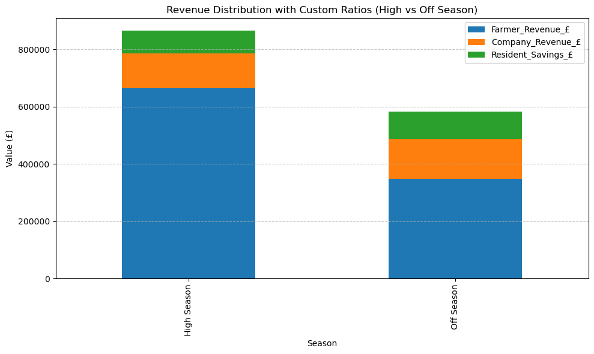

```python
# Define custom season-specific sharing ratios
season_ratios = {
    'High Season': (0.50, 0.30, 0.20),  # More benefit to farmers during peak generation
    'Off Season': (0.40, 0.35, 0.25)    # More balanced distribution in lower generation months
}

# Apply new seasonal mapping
telemetry_hourly_clean['Month'] = telemetry_hourly_clean.index.month
telemetry_hourly_clean['Season'] = telemetry_hourly_clean['Month'].apply(
    lambda m: 'High Season' if m in [10, 11, 12, 1, 2, 3, 4] else 'Off Season'
)

# Calculate adjusted seasonal revenue distribution
adjusted_seasonal_summary = []

for season, group in telemetry_hourly_clean.groupby('Season'):
    curtailed_energy = group['Curtailment_kw'].sum()
    base_energy = group['Power_kw'].sum()
    avoided_value = curtailed_energy * wholesale_price
    base_revenue = base_energy * wholesale_price

    farmer_share, company_share, resident_share = season_ratios[season]

    adjusted_seasonal_summary.append({
        'Season': season,
        'Total_Energy_kWh': base_energy + curtailed_energy,
        'Curtailment_kWh': curtailed_energy,
        'Avoided_Curtailment_Value_£': avoided_value,
        'Farmer_Revenue_£': base_revenue + avoided_value * farmer_share,
        'Company_Revenue_£': avoided_value * company_share,
        'Resident_Savings_£': avoided_value * resident_share
    })

# Create DataFrame
adjusted_seasonal_df = pd.DataFrame(adjusted_seasonal_summary).round(2)

# Plot results
adjusted_seasonal_df.set_index('Season')[['Farmer_Revenue_£', 'Company_Revenue_£', 'Resident_Savings_£']].plot(
    kind='bar', stacked=True, figsize=(10, 6)
)
plt.title('Revenue Distribution with Custom Ratios (High vs Off Season)')
plt.ylabel('Value (£)')
plt.xlabel('Season')
plt.grid(axis='y', linestyle='--', alpha=0.7)
plt.tight_layout()
plt.show()
```

#### Demand Estimation

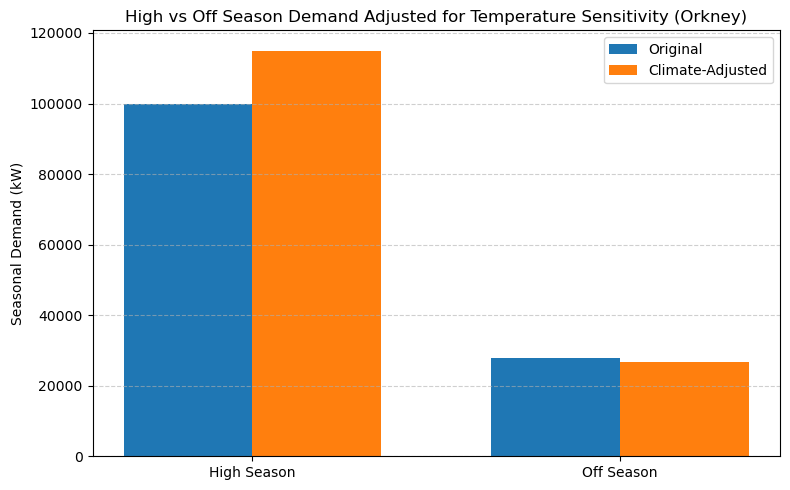

|  | Original Demand (kW) | Climate Adjusted Demand (kW) |
| --- | --- | --- |
| High Season | 100000 | 115000.0 |
| Off Season | 28000 | 26600.0 |

```python
# Redefine seasonal demand based on high season (Oct–Apr) and off season (May–Sep)
seasonal_summary_custom = pd.DataFrame({
    "Total Demand (kW)": {
        'High Season': 35000 + 32000 + 33000,  # Winter, Spring, Autumn combined (approximation)
        'Off Season': 28000  # Summer
    }
})

# Define temperature sensitivity multipliers for the two-season model
custom_multipliers = {
    'High Season': 1.15,  # Increase due to heating
    'Off Season': 0.95   # Decrease due to reduced load
}

# Apply multipliers
climate_adjusted_custom = seasonal_summary_custom["Total Demand (kW)"] * seasonal_summary_custom.index.map(custom_multipliers)

# Create comparison DataFrame
comparison_custom_df = pd.DataFrame({
    "Original Demand (kW)": seasonal_summary_custom["Total Demand (kW)"],
    "Climate Adjusted Demand (kW)": climate_adjusted_custom
}).round(1)

# Plot
plt.figure(figsize=(8, 5))
bar_width = 0.35
x = range(len(comparison_custom_df))

plt.bar(x, comparison_custom_df["Original Demand (kW)"], width=bar_width, label='Original')
plt.bar([p + bar_width for p in x], comparison_custom_df["Climate Adjusted Demand (kW)"], width=bar_width, label='Climate-Adjusted')

plt.xticks([p + bar_width / 2 for p in x], comparison_custom_df.index)
plt.ylabel("Seasonal Demand (kW)")
plt.title("High vs Off Season Demand Adjusted for Temperature Sensitivity (Orkney)")
plt.legend()
plt.grid(axis='y', linestyle='--', alpha=0.6)
plt.tight_layout()
plt.show()

comparison_custom_df
```

# Appendix D - Stakeholder Pricing

### Wind Farmer Pricing

#### WF - Causal Summary

```python
print(model_varied.summary())
```

```
                            OLS Regression Results
==============================================================================
Dep. Variable:                    dif   R-squared:                       0.216
Model:                            OLS   Adj. R-squared:                  0.215
Method:                 Least Squares   F-statistic:                     137.8
Date:                Thu, 29 May 2025   Prob (F-statistic):               0.00
Time:                        20:46:24   Log-Likelihood:            -2.1659e+05
No. Observations:               17520   AIC:                         4.333e+05
Df Residuals:                   17484   BIC:                         4.335e+05
Df Model:                          35
Covariance Type:            nonrobust
==================================================================================
                     coef    std err          t      P>|t|      [0.025      0.975]
----------------------------------------------------------------------------------
Intercept       1.096e+06   3.87e+04     28.324      0.000    1.02e+06    1.17e+06
C(month)[T.2]  -4419.8298   2132.234     -2.073      0.038   -8599.221    -240.439
C(month)[T.3]  -1.732e+04   2077.007     -8.340      0.000   -2.14e+04   -1.33e+04
C(month)[T.4]   1361.4148   2094.558      0.650      0.516   -2744.128    5466.957
C(month)[T.5]  -1.694e+05   4902.555    -34.560      0.000   -1.79e+05    -1.6e+05
C(month)[T.6]  -1.638e+05   4823.428    -33.954      0.000   -1.73e+05   -1.54e+05
C(month)[T.7]  -1.804e+05   4847.065    -37.211      0.000    -1.9e+05   -1.71e+05
C(month)[T.8]  -1.735e+05   4814.682    -36.034      0.000   -1.83e+05   -1.64e+05
C(month)[T.9]  -1.531e+05   4822.305    -31.744      0.000   -1.63e+05   -1.44e+05
C(month)[T.10]  -1.02e+04   2079.585     -4.903      0.000   -1.43e+04   -6119.960
C(month)[T.11]  1.877e+04   2094.175      8.963      0.000    1.47e+04    2.29e+04
C(month)[T.12] -4526.0265   2078.998     -2.177      0.029   -8601.070    -450.983
C(hour)[T.1]   -1615.4981   2965.275     -0.545      0.586   -7427.734    4196.737
C(hour)[T.2]    -594.3968   2965.269     -0.200      0.841   -6406.620    5217.826
C(hour)[T.3]    -645.7772   2965.266     -0.218      0.828   -6457.994    5166.440
C(hour)[T.4]     -40.4348   2965.269     -0.014      0.989   -5852.658    5771.788
C(hour)[T.5]     896.9913   2965.266      0.302      0.762   -4915.225    6709.208
C(hour)[T.6]    1862.4510   2965.273      0.628      0.530   -3949.780    7674.682
C(hour)[T.7]     906.6301   2965.266      0.306      0.760   -4905.587    6718.847
C(hour)[T.8]     381.1063   2965.375      0.129      0.898   -5431.325    6193.537
C(hour)[T.9]    2471.9221   2965.397      0.834      0.405   -3340.552    8284.396
C(hour)[T.10]   4405.8555   2965.383      1.486      0.137   -1406.591    1.02e+04
C(hour)[T.11]   4854.1027   2965.502      1.637      0.102    -958.577    1.07e+04
C(hour)[T.12]   6760.3329   2965.455      2.280      0.023     947.746    1.26e+04
C(hour)[T.13]   4347.0711   2966.122      1.466      0.143   -1466.823    1.02e+04
C(hour)[T.14]   3779.5993   2966.093      1.274      0.203   -2034.238    9593.436
C(hour)[T.15]   3068.5057   2965.941      1.035      0.301   -2745.034    8882.045
C(hour)[T.16]   2648.5087   2965.753      0.893      0.372   -3164.662    8461.680
C(hour)[T.17]   3136.5131   2965.273      1.058      0.290   -2675.718    8948.744
C(hour)[T.18]   2473.5322   2965.270      0.834      0.404   -3338.692    8285.756
C(hour)[T.19]   1793.3854   2965.266      0.605      0.545   -4018.832    7605.602
C(hour)[T.20]   1486.8196   2965.274      0.501      0.616   -4325.413    7299.052
C(hour)[T.21]   2087.6941   2965.291      0.704      0.481   -3724.572    7899.960
C(hour)[T.22]   1541.0645   2965.309      0.520      0.603   -4271.236    7353.365
C(hour)[T.23]    375.7096   2965.295      0.127      0.899   -5436.564    6187.983
Price_var      -5.816e+06   2.24e+05    -25.938      0.000   -6.26e+06   -5.38e+06
==============================================================================
Omnibus:                     3660.580   Durbin-Watson:                   0.093
Prob(Omnibus):                  0.000   Jarque-Bera (JB):              712.219
Skew:                           0.051   Prob(JB):                    2.21e-155
Kurtosis:                       2.018   Cond. No.                         569.
==============================================================================

Notes:
[1] Standard Errors assume that the covariance matrix of the errors is correctly specified.
```

#### WF - Price Reductions

```python
# Add Month and Hour for grouping
supply_vs['Month'] = supply_vs.index.month
supply_vs['Hour'] = supply_vs.index.hour

# How much was price reduced
supply_vs['Price_Reduction'] = supply_vs['Price_var'] - supply_vs['Price_sim']

# How much additional energy was sold (kWh)
supply_vs['Extra_Energy_Sold'] = supply_vs['Predicted_demand'] - supply_vs['dif']
supply_vs['Extra_Energy_Sold'] = supply_vs['Extra_Energy_Sold'].clip(lower=0)

# Calculate total extra demand and average price drop per group
grouped_strategy = (
    supply_vs.groupby(['Month', 'Hour'])
    .agg(
        Total_Extra_Energy_Sold=('Extra_Energy_Sold', 'sum'),
        Avg_Price_Reduction=('Price_Reduction', lambda x: round(x.mean(), 3)),
        Times_Price_Reduced=('Price_Reduction', lambda x: (x > 0).sum())
    )
    .reset_index()
)
```

```python
strategy_zones = grouped_strategy[
    (grouped_strategy['Total_Extra_Energy_Sold'] > 100000) &  # e.g., > 100,000 kWh
    (grouped_strategy['Times_Price_Reduced'] > 20)             # e.g., at least 20 intervals
]

strategy_zones_sorted = strategy_zones.sort_values(by='Total_Extra_Energy_Sold', ascending=False)
```

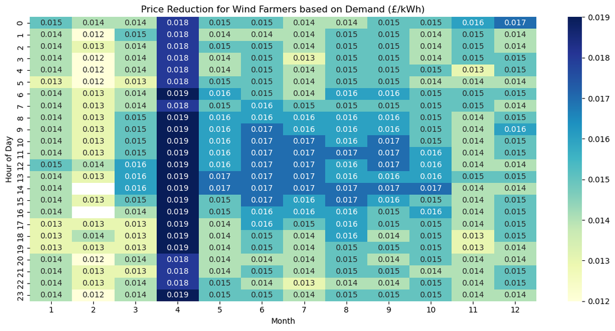

```python
pivot = strategy_zones.pivot(index = 'Hour', columns = 'Month', values = 'Avg_Price_Reduction')
plt.figure(figsize=(12,6))
sns.heatmap(pivot, cmap="YlGnBu", annot=True)
plt.title("Price Reduction for Wind Farmers based on Demand (£/kWh)")
plt.xlabel("Month")
plt.ylabel("Hour of Day")
plt.tight_layout()
plt.show()
```

### Energy Provider Pricing

#### EP - Causal Summary

```python
print(consumer_model.summary())
```

```
                            OLS Regression Results
==============================================================================
Dep. Variable:                    dif   R-squared:                       0.220
Model:                            OLS   Adj. R-squared:                  0.219
Method:                 Least Squares   F-statistic:                     141.2
Date:                Thu, 29 May 2025   Prob (F-statistic):               0.00
Time:                        21:14:42   Log-Likelihood:            -2.1655e+05
No. Observations:               17520   AIC:                         4.332e+05
Df Residuals:                   17484   BIC:                         4.334e+05
Df Model:                          35
Covariance Type:            nonrobust
======================================================================================
                         coef    std err          t      P>|t|      [0.025      0.975]
--------------------------------------------------------------------------------------
Intercept           1.112e+06   3.68e+04     30.218      0.000    1.04e+06    1.18e+06
C(hour)[T.1]       -1646.1216   2957.512     -0.557      0.578   -7443.139    4150.896
C(hour)[T.2]        -671.7692   2957.506     -0.227      0.820   -6468.775    5125.237
C(hour)[T.3]        -794.7227   2957.508     -0.269      0.788   -6591.732    5002.287
C(hour)[T.4]        -283.3386   2957.534     -0.096      0.924   -6080.401    5513.723
C(hour)[T.5]         710.1861   2957.515      0.240      0.810   -5086.838    6507.210
C(hour)[T.6]        1776.4602   2957.520      0.601      0.548   -4020.575    7573.495
C(hour)[T.7]         853.7566   2957.507      0.289      0.773   -4943.252    6650.766
C(hour)[T.8]         377.2047   2957.600      0.128      0.899   -5419.987    6174.396
C(hour)[T.9]        2598.1311   2957.665      0.878      0.380   -3199.187    8395.449
C(hour)[T.10]       4394.9078   2957.605      1.486      0.137   -1402.294    1.02e+04
C(hour)[T.11]       4876.5977   2957.723      1.649      0.099    -920.834    1.07e+04
C(hour)[T.12]       6987.5465   2957.770      2.362      0.018    1190.023    1.28e+04
C(hour)[T.13]       4580.3836   2958.459      1.548      0.122   -1218.491    1.04e+04
C(hour)[T.14]       3825.6459   2958.269      1.293      0.196   -1972.856    9624.148
C(hour)[T.15]       3020.1332   2958.064      1.021      0.307   -2777.967    8818.233
C(hour)[T.16]       2442.5724   2957.816      0.826      0.409   -3355.042    8240.187
C(hour)[T.17]       3011.7959   2957.506      1.018      0.309   -2785.210    8808.802
C(hour)[T.18]       2312.3374   2957.506      0.782      0.434   -3484.668    8109.343
C(hour)[T.19]       1706.3378   2957.509      0.577      0.564   -4090.675    7503.351
C(hour)[T.20]       1450.9380   2957.516      0.491      0.624   -4346.088    7247.964
C(hour)[T.21]       1807.9873   2957.584      0.611      0.541   -3989.172    7605.147
C(hour)[T.22]       1382.2537   2957.578      0.467      0.640   -4414.893    7179.401
C(hour)[T.23]        119.9056   2957.584      0.041      0.968   -5677.254    5917.065
C(month)[T.2]      -4889.0996   2126.978     -2.299      0.022   -9058.189    -720.010
C(month)[T.3]      -1.692e+04   2071.726     -8.166      0.000    -2.1e+04   -1.29e+04
C(month)[T.4]        906.5578   2089.390      0.434      0.664   -3188.854    5001.970
C(month)[T.5]      -5.512e+04   2071.744    -26.606      0.000   -5.92e+04   -5.11e+04
C(month)[T.6]      -5.021e+04   2088.927    -24.037      0.000   -5.43e+04   -4.61e+04
C(month)[T.7]      -6.638e+04   2071.551    -32.043      0.000   -7.04e+04   -6.23e+04
C(month)[T.8]      -5.992e+04   2071.763    -28.921      0.000    -6.4e+04   -5.59e+04
C(month)[T.9]      -3.949e+04   2088.955    -18.906      0.000   -4.36e+04   -3.54e+04
C(month)[T.10]     -8922.4269   2076.510     -4.297      0.000    -1.3e+04   -4852.261
C(month)[T.11]      1.889e+04   2088.700      9.043      0.000    1.48e+04     2.3e+04
C(month)[T.12]     -3692.5893   2074.785     -1.780      0.075   -7759.375     374.197
Consumer_Price_var -6.153e+06   2.22e+05    -27.716      0.000   -6.59e+06   -5.72e+06
==============================================================================
Omnibus:                     2983.502   Durbin-Watson:                   0.093
Prob(Omnibus):                  0.000   Jarque-Bera (JB):              653.572
Skew:                           0.039   Prob(JB):                    1.20e-142
Kurtosis:                       2.057   Cond. No.                         564.
==============================================================================

Notes:
[1] Standard Errors assume that the covariance matrix of the errors is correctly specified.
```

#### EP - Price Reductions

```python
# How much was price reduced
supply_vs['Consumer_Price_Reduction'] = supply_vs['Consumer_Price_var'] - supply_vs['Consumer_price_sim']

# How much additional energy was sold (kWh)
supply_vs['Consumer_Extra_Energy_Sold'] = supply_vs['Predicted_Household_Demand'] - supply_vs['dif']
supply_vs['Consumer_Extra_Energy_Sold'] = supply_vs['Consumer_Extra_Energy_Sold'].clip(lower=0)

# Calculate total extra demand and average price drop per group
consumer_grouped_strategy = (
    supply_vs.groupby(['Month', 'Hour'])
    .agg(
        Consumer_Total_Extra_Energy_Sold=('Consumer_Extra_Energy_Sold', 'sum'),
        Consumer_Avg_Price_Reduction=('Consumer_Price_Reduction', lambda x: round(x.mean(), 3)),
        Consumer_Times_Price_Reduced=('Consumer_Price_Reduction', lambda x: (x > 0).sum())
    )
    .reset_index()
)

consumer_strategy_zones = consumer_grouped_strategy[
    (consumer_grouped_strategy['Consumer_Total_Extra_Energy_Sold'] > 100000) &  # e.g., > 100,000 kWh
    (consumer_grouped_strategy['Consumer_Times_Price_Reduced'] > 20)             # e.g., at least 20 intervals
]
```

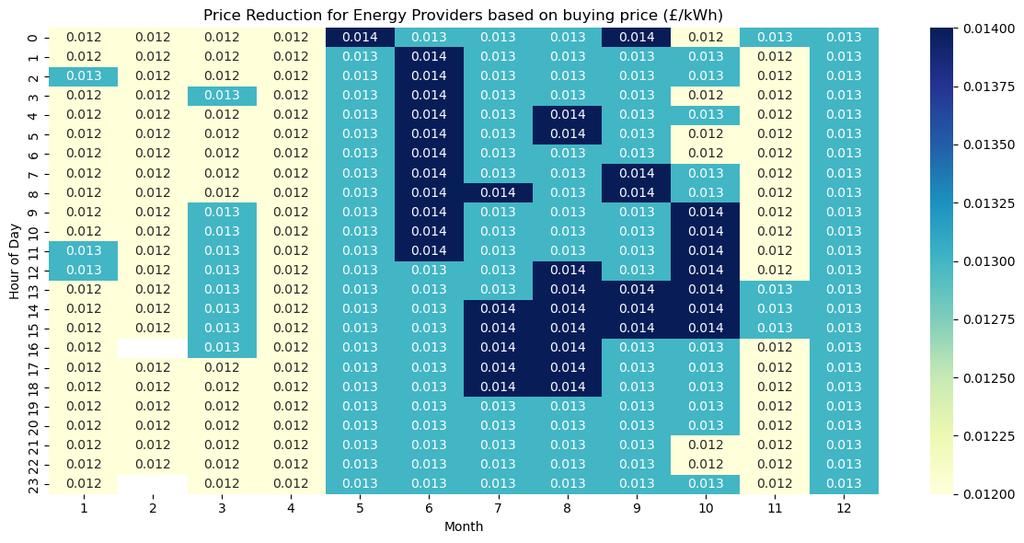

```python
pivot = consumer_strategy_zones.pivot(index = 'Hour', columns = 'Month', values = 'Consumer_Avg_Price_Reduction')
plt.figure(figsize=(12,6))
sns.heatmap(pivot, cmap="YlGnBu", annot=True)
plt.title("Price Reduction for Energy Providers based on buying price (£/kWh)")
plt.xlabel("Month")
plt.ylabel("Hour of Day")
plt.tight_layout()
plt.show()
```

### Forecast Summary

#### Wind Farmers

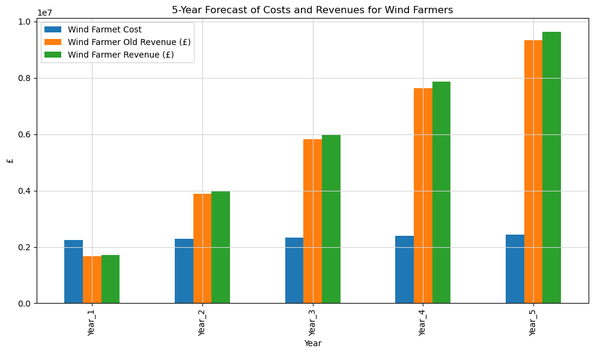

```python
(farmer_summary.set_index('Year')[['Wind Farmet Cost', 'Wind Farmer Old Revenue (£)', 'Wind Farmer Revenue (£)']] * 0.1).plot(kind='bar', figsize=(10,6))
plt.ylabel('£')
plt.title('5-Year Forecast of Costs and Revenues for Wind Farmers')
plt.grid(True, color = 'lightgrey')
plt.tight_layout()
plt.show()
```

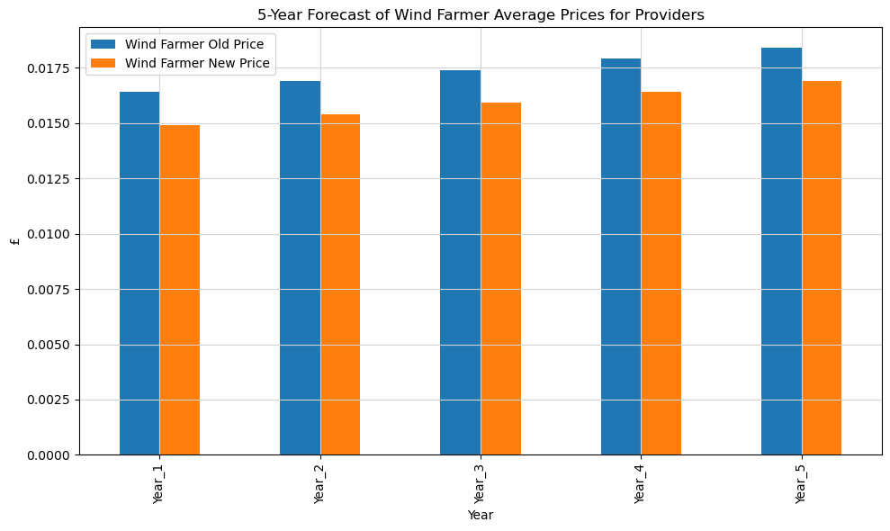

```python
# Optional: plot revenues
(farmer_summary.set_index('Year')[['Wind Farmer Old Price', 'Wind Farmer New Price']] * 0.1).plot(kind='bar', figsize=(10,6))
plt.ylabel('£')
plt.title('5-Year Forecast of Wind Farmer Average Prices for Providers')
plt.grid(True, color = 'lightgrey')
plt.tight_layout()
plt.show()
```

#### Energy Providers

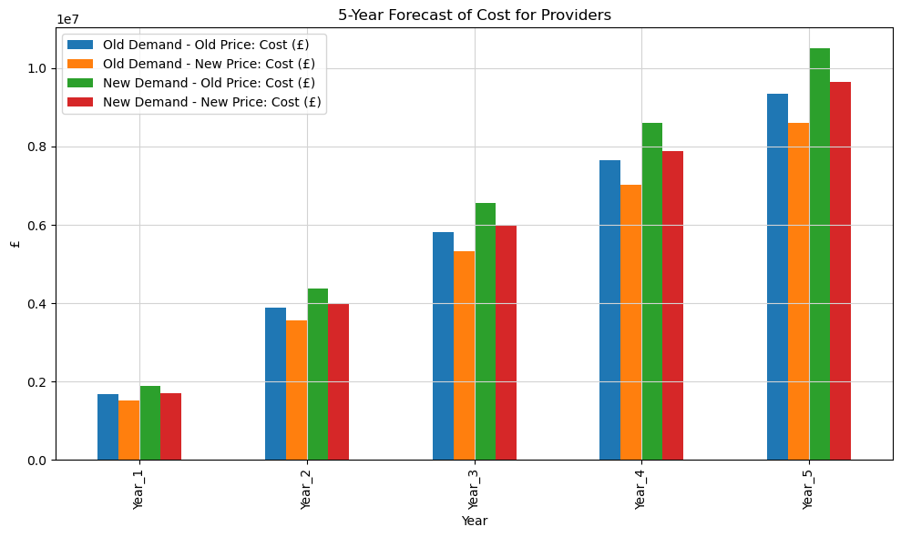

```python
(provider_summary.set_index('Year')[['Old Demand - Old Price: Cost (£)', 'Old Demand - New Price: Cost (£)', 'New Demand - Old Price: Cost (£)', 'New Demand - New Price: Cost (£)']] * 0.1).plot(kind='bar', figsize=(10,6))
plt.ylabel('£')
plt.title('5-Year Forecast of Cost for Providers')
plt.grid(True, color = 'lightgrey')
plt.tight_layout()
plt.show()
```

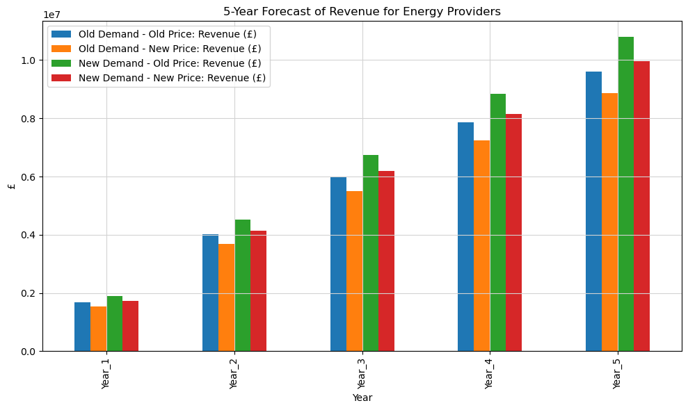

```python
(provider_summary.set_index('Year')[['Old Demand - Old Price: Revenue (£)', 'Old Demand - New Price: Revenue (£)', 'New Demand - Old Price: Revenue (£)', 'New Demand - New Price: Revenue (£)']] * 0.1).plot(kind='bar', figsize=(10,6))
plt.ylabel('£')
plt.title('5-Year Forecast of Revenue for Energy Providers')
plt.grid(True, color = 'lightgrey')
plt.tight_layout()
plt.show()
```

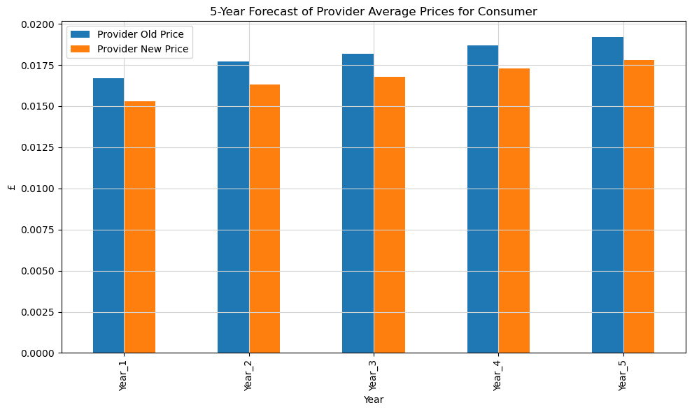

```python
(provider_summary.set_index('Year')[['Provider Old Price', 'Provider New Price']] * 0.1).plot(kind='bar', figsize=(10,6))
plt.ylabel('£')
plt.title('5-Year Forecast of Provider Average Prices for Consumer')
plt.grid(True, color = 'lightgrey')
plt.tight_layout()
plt.show()
```

#### Consumers

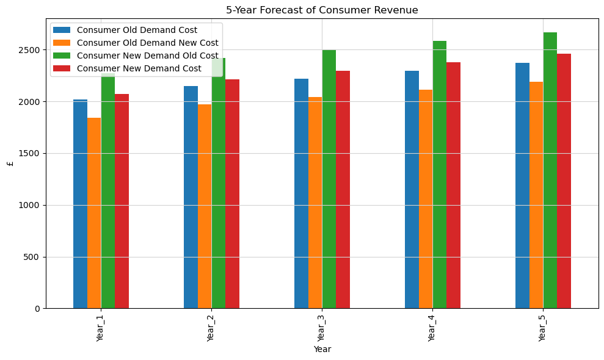

```python
(consumer_summary.set_index('Year')[['Consumer Old Demand Cost', 'Consumer Old Demand New Cost', 'Consumer New Demand Old Cost', 'Consumer New Demand Cost']] * 0.1).plot(kind='bar', figsize=(10,6))
plt.ylabel('£')
plt.title('5-Year Forecast of Consumer Revenue')
plt.grid(True, color = 'lightgrey')
plt.tight_layout()
plt.show()
```